# Introduction to R Part1

## R mathematical expressions

Since we are in the topic of mathematical operations below is a list with some basic built-in mathematical functions you can use in R:

- `sqrt(x)`: Returns the square root of the input value.  
  Example:

```r
sqrt(467)
```

```
## [1] 21.61018
```

- `abs(x)`: Returns the absolute value.  
  Example:

```r
abs(-32)
```

```
## [1] 32
```

```r
floor(34.56) #rounds down to the nearest integer
```

```
## [1] 34
```

```r
#You can also combine expressions:
floor(sqrt(476))
```

```
## [1] 21
```

- `ceiling(x)`: Returns the smallest integer which is larger than or equal to the input value.  
  Example:

```r
ceiling(sqrt(476)) #rounds up to the nearest integer
```

```
## [1] 22
```

- `round(x)`: Returns round value of input.  
  Example:

```r
round(sqrt(476))
```

```
## [1] 22
```

```r
#We can also specify the number of significant digits
round(sqrt(476), digits=2)
```

```
## [1] 21.82
```

- `sin(x)`, `cos(x)`, `tan(x)`: Returns the sin(x), cos(x), and tan(x).

Example:

```r
sin(34)
```

```
## [1] 0.5290827
```

Since the above calculation produces a number with many decimal points we can reduce them by using the round() function.  
Example:

```r
round(sin(34), dig=2)
```

```
## [1] 0.53
```

- `exp(x)`: Returns the exponent of the input value (natural exponential function).  
  Example:

```r
exp(5)
```

```
## [1] 148.4132
```

- `log10(x)`, `log2(x)`: Returns the common logarithm (base10) and the logarithm (base2) respectively of the input value.
- `log(x)`: Returns the natural logarithm (base e) of the input value

An example on how to use some of the above expressions is given below. Feel free to try on your own

```r
#Natural logarithm
log(10^5)
```

```
## [1] 11.51293
```

```r
#Common algorithm
log10(10^5)
```

```
## [1] 5
```

We can also use special symbols to denote mathematical expressions. For example: `pi` for mathematical $\pi$.  
Example:

```r
pi/2 + sqrt(3)
```

```
## [1] 3.302847
```

`i` for illogical (complex) numbers

```r
3i + 54
```

```
## [1] 54+3i
```

That was fun, but R can do much more than being a simple calculator! In the following sections we will explore ways to use R to make the most out of our data.

## Storing and reusing results

Previously we did some simple mathematical calculations. However, the results of those calculations was not stored anywhere. If you want to store a specific value or the result of an operation in R so they are available to use later, you need to use the **assignment** operator `<-` which consists of two separate characters `<` and `-` with no space between them. This assignment operator is rather unique to R but in most cases we can also use `=` as an assignment operator which is similar to other programming languages.  
Lets see some simple examples:

```r
a <- 5

b <- 8
```

So what happened there? We asked R to first evaluate the expression on the right hand side of each `<-` (just a number in this case) and then associate the result of that evaluation to a **variable** called `a` and `b` respectively. Now type the letter `a` into the console and hit Enter:

```r
a
```

```
## [1] 5
```

It looks as if we typed the number `5` directly to the console. Try the same for variable `b`. Hopefully you got the number `8` appearing in the console.  
We can now use variables `a` and `b` to do different mathematical calculations. To save the results of those calculations we need to assign them to new variables. E.g.

```r
c <- a + b

# Print result in console
c
```

```
## [1] 13
```

```r
d <- 2*a + b^3 -log(a)

#Print result in console
d
```

```
## [1] 520.3906
```

We can also *modify* the value of a variable. E.g.

```r
a <- 10
```

Now print the value of `a` in the console. You will see it has changed to `10` instead of `5` earlier.  
You need to be careful not to modify a variable accidentally as you may get unexpected results.

## R Naming Rules

To name a variable in R we can use any sequence of alphanumeric symbols (letters and numbers), as well as the symbols `.` and`_`, with the restriction that a name must start with `.` or a letter, and if it starts with `.` the second character must NOT be a digit.  
Both upper and lower case letters are allowed.  
For example, `exam_1`, `exam.1`, `exam1`, `EXAM1`, `myExam1` are all perfectly acceptable names, but `1exam` and `_exam1` are not because they begin with `1` and `_`.  
Also, make sure the names assigned to a variable make sense. It will help you decipher what this variable is about.  
Finally, refrain from using “reserved” words to name your variables. For instance `TRUE`, `FALSE`, `repeat`, `while`, `if`, `else`, `for`, are some examples of “reserved” words already being used by R.

### R Case Sensitivity

R is case sensitive so `a` and `A` for instance correspond to different variables. The same is true for `data` and `Data` for example.

⚠️**CAUTION**: Although as mentioned above we are allowed to start a name with `.` this is usually a BAD IDEA!. A variable starting with a period is hidden by default; the value it refers to exists but it’s invisible. While it can be useful in certain cases, it is outside the scope of this course.

## The Global Environment

Whenever we perform an assignment in the Console the variable created is placed into the **Global Environment**. The current set of variables are all listed in the **Environment** tab in RStudio. Assuming that at least one variable has been created, there will be two columns in the Environment tab. The first shows the names of all the variables, while the second shows their values.

⚠️**ATTENTION** If we quit the R and R Studio session which is currently running and reopen it the Global Environment will be empty. Later on we will learn how to save the Global Environment to allow us to access it any time we want.

## Using Functions in R

Until now we have not done anything too complicated in R. Yet we already learned how to use some of the *functions* available in R to perform some mathematical calculations.  
**A function is defined as the basic building block of any programming language which allows us to perform complex calculations or computations in a single line.**  
Therefore, to use R effectively, even for relatively simple tasks we need to make ourselves familiar with the concept of functions.

Functions are particularly useful for performing repetitive tasks while providing us with the flexibility to retain some control over the precise details of what is actually happening. To do this we need to provide *arguments*.  
To better illustrate this we will look at some examples of the built-in functions we already encountered earlier.

Let’s take the example of the `round()` function which is used to round one (or more) numbers to a significant number of digits.

```r
round(x=pi, digits=2)
```

```
## [1] 3.14
```

To use the function above we need to call the function name followed by round brackets (**()**), where we put the arguments.  
- The first argument is the input data x, i.e. the number(s) we want to round.  
- The second argument is the number of significant digits we want to retain.  
To set the value for each argument we use the `(=)` symbol (x = pi, digits = 2).  
Under the hood the function consists of some lines of code which perform the calculation we want to do given the specific arguments we have provided.

## Built-in R Functions

Apart from the mathematical built-in function we encountered earlier, R has a number of built-in functions which allow us to perform the basic tasks. The schema below illustrates the types of built-in function R provides.

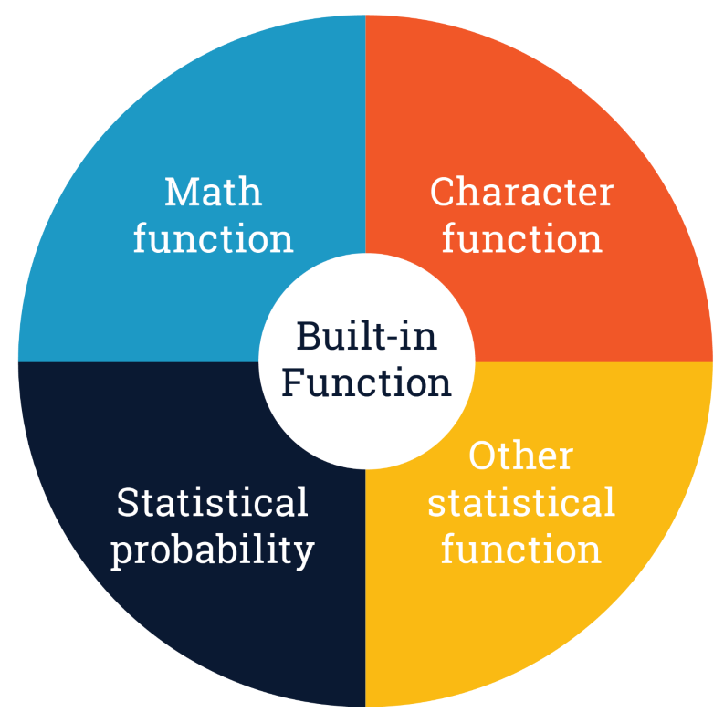

This is for reference only at this point. In the next tutorials we will learn to use some of these functions for different tasks. We will also learn how to make functions from scratch, which will give you a good idea what is happening behind the scenes!

## Creating Scripts in R

Working directly in the Console is not recommended. To save your work and be able to repeat the analysis or edit it you should create a “script”. A script is essentially a text file where we put our sequence of R expressions which are instructions telling the computer what to do.  
To create a new script in R go to `File > New File` and select the type of file you want to create. E.g. `R Script` or `R Markdown`. This will open the new file in a fourth pane. This pane is the **Source Code Editor**.  
To save the new script go to `File > Save As` and save the file in the folder of your choice.  
To customise the appearance of your text editor, you can go to `Tools > Global Options > Appearance` and choose the font, theme etc. that you like.

*Important to Remember:* When we work with a script we type the required sequence of R expressions into the Editor pane, not directly into the Console. Also switching between the Editor and the Console is highly discouraged as it can lead to non-functional script.

## Setting the working directory

When creating an new R or Rmd script one of the first things to do is set your *working directory*. There are several ways you can do this. For example click on `Session` `Set Working Directory` `Choose Directory` or go to the bottom right panel in R Studio click on `Files`and navigate to the Folder you want to set as working directory. Then click on the *cog* icon and select `Set as Working Directory` from the drop down menu.

[figure not shown]

Finally you can set the working directory by typing `setwd()` and providing the path to the folder you want to set as working directory. For example:

```r
knitr::opts_knit$set(root.dir = "~/Bioinformatics_MSc/Teaching/Academic Year 2024-2025/Soils Mastership/Tutorials")
```

⚠️ **Caution** The above path works only on my computer! You need to provide the specific path to your working directory.

To check which is your current working directory you can type `getwd()`. Try it for yourselves.

The next step is to clear your working environment from any previous objects and graphics.

```r
# Clear working Environment
rm(list=ls())

# Close graphics devices
graphics.off()
```

## Loading additional packages

As we mentioned in our course introduction, R has thousands of additional packages (libraries) which can be installed via `installed.packages()`and subsequently loaded every time you execute a script.

```r
#Load an R package
library(car)
```

Or alternatively:

```r
require(car)
```

## Sourcing additional Functions

When you get more proficient in R and start creating your own function you will realise that keeping them in your main script is not a good idea as it makes things messy. In this case it is advised to save your function in a separate R script and “source” them when running the main script containing your analysis. To source a script you use the function `source()` with the name of the script inside the round brackets.  
For example:

```r
source("MyFunction.r")
```

This action will make the functions you sourced available for your analysis.

## Accessing Help in R

R has an inbuilt help facility which allow us to get information on functions and features. To use the R help facility to get more information on any specific function, we can write:

```r
help ("sample")
```

Or alternatively you can write:

```r
?sample
```

The information for this function will appear in the right bottom pane in RStudio.

## Commenting your code

When creating your scripts it is very important to add comments. Comments in R always start with a `#` symbol. Lines that start with # are completely ignored by R when the code is executed, but they are very helpful to keep track of the analysis process and explain the logic behind each step. So, don’t forget comments!!

## Errors

One of the most scary things that can happen when you are a beginner in R and programming in general, is having an error. In R errors are displayed in the form or a message in red font which appear in the console when we execute a piece of code. Error messages can cause a bit of a panic especially when we have no idea what they mean. Don’t worry this happens to the most experienced R users.

Let’s see a simple example:

```r
#Define variable z:
z<-23 + 565*exp(-2)

#print z in the console
z
```

```
## [1] 99.46444
```

The next step is to use the variable z you created above in a new mathematical expression

```r
#y <- 45 + log(Z-5)
```

You should see an error message saying: “Error: object ‘Z’ not found”. Any ideas what this means?

Let’s sort this error and try again:

```r
y <- 45 + log(z-5)

#print y
y
```

```
## [1] 49.54822
```

Always **read the error messages**. They might be confusing at first, but they will eventually start to make some sense and point you to the right direction.

## Writing you first script

**Exercise**: In this exercise you are required to create a script to solve a second order equation.  
A second order equation is written as:

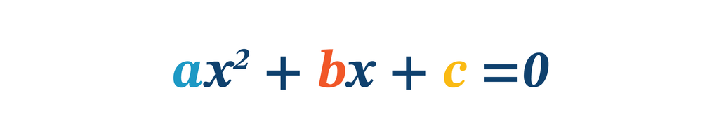

And the solution to this equation is given by the following mathematical formula:

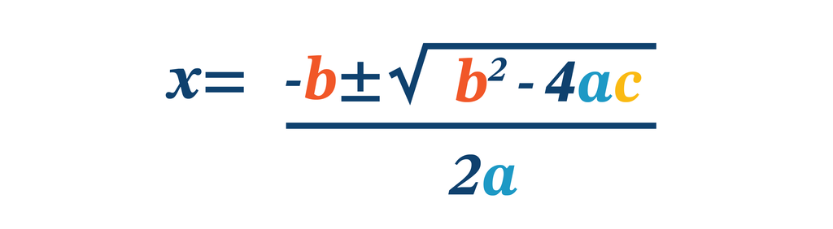

```r
#The values for a, b, and c are given below
a <- 2
b <- 5
c <- 3

# Write the expression for the first solution and save it under variable x1


# Write the expression for the second solution and save it under variable x2
```

Now print the solutions (if they exist) in the console:

```r
# Print the solutions x1 and x2 in the console.
paste("solution 1 is x1 =" )   # Fill in the missing variable
```

```
## [1] "solution 1 is x1 ="
```

```r
paste("solution 2 is x2 =" )   # Fill in the missing variable
```

```
## [1] "solution 2 is x2 ="
```

### Final Note: Syntax Highliting.

As you have already noticed by now, when we create an R script, parts of the R code is formatted by colour. This is called **syntax highlighting** and is a must have feature of any Editor. The purpose of syntax highlighting is to draw attention to different components of syntax. Depending on the Font option you have selected, RStudio uses different colours to display variables, parentheses, arithmetic operators, and numbers, which makes it much easier when reviewing a script.

## Managing Data

### Inspecting the workspace

We can use the function `ls()` to print a list of all the variables present in the workspace.

```r
ls()
```

```
## [1] "a" "b" "c" "y" "z"
```

### Removing variables

Occasionally you might want to remove a variable from your Global Environment. We can do this using the `rm()` function

```r
rm(a)
```

We can also remove several variables at once.

```r
rm(list=c("a", "b", "c"))
```

To check if this has worked use the `ls()` function again. Are variables `a`, `b` and `c` present in your workspace?

You can also combine the `rm()` and `ls()` functions in order to clear the entire workspace.

```r
rm(list=ls())
```

### Saving data structures

The `save()` function saves one or more data structures to a file:

```r
#save(x, y, z, file = "mydata.Rdata")
```

The load() command can recreate any data structures saved with `save()`.

```r
#load("mydata.RData")
```

### Saving the Workspace

If we want to save the entire workspace so that it is available to carry on working next time we open RStudio, we can use the `save.image()` function.

```r
save.image(file='MyScript.Environment.RData')
```

Then you can load again the workspace using the `load()` function as earlier.

## Importing Data in R

Although we can create some small datasets within R, this is not the most efficient way to work with data. In the majority of situations, you will need to access your data from different sources depending if they are experimental data, publicly available data, survey results and so on. Luckily, R is able to access data from a huge range of different data storage formats and repositories. We can use R to pull in data from various databases, proprietary storage formats (e.g. Excel), online web sites, or plain text files. For the purpose of this course we will only examine the simplest method for data import: reading in data from a text file, namely **.txt** and **.csv** formats.

Before we proceed, we need to make sure that we have set our working directory, as this is where R will be looking to import the data from. In the previous section we already learned how to set the working directory and how to check which is the current working directory.

The main function in R for importing text files is `read.table()`. This function reads a file in table format and creates a data frame from it. The main syntax for this function is depicted in the schema below:

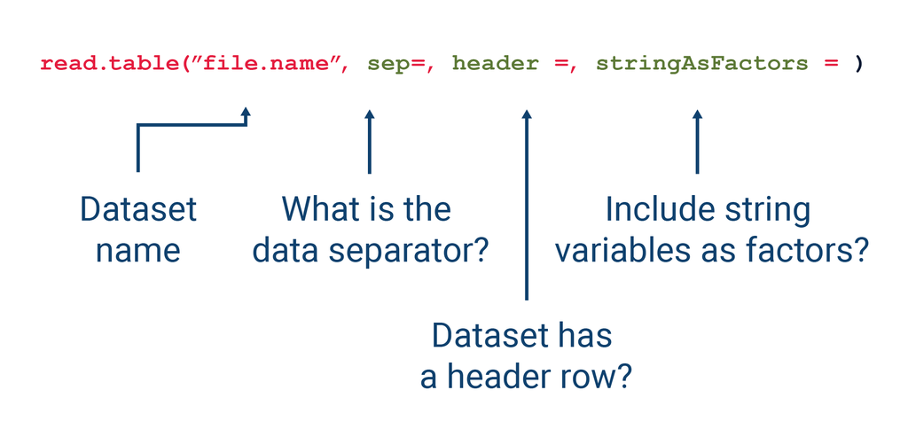

**Example**: Let’s see an example to understand how this works in practice. You have been supplied with a csv file named **honey_sugar.csv** which contains the sugar content(%) and water content(%) of 54 honey samples from across the UK. We want to import this file into R so we can carry on some data analysis.

```r
honey.data <- read.table("Data/honey_sugar.csv", sep = ",", header = TRUE, stringsAsFactors = FALSE)
```

The most common text files you will encounter and their separators are the following:

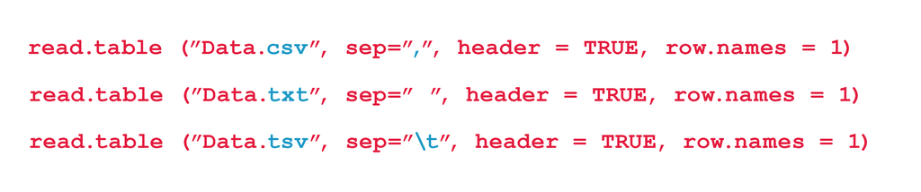

**Importing CSV files with `read.csv()`** For CSV you can also use the `read.csv()` function.

```r
honey.data <- read.csv("Data/honey_sugar.csv", sep = ",", header = TRUE, stringsAsFactors = FALSE)
```

**NOTE** If we haven’t set the working directory, we will need to give the full path to the folder our data file is located. However, this is not recommended.

### Exporting tables from R

Conveniently we can also export tables that we created or modified in R and save them in a local folder. We can use the `write.table()` function or alternatively the `write.csv()` function specifically for exporting csv files.

```r
write.table(honey.data, file="honey_data.csv", row.names = FALSE)
```

⚠️**IMPORTANT** In the previous example we set the argument for `row.name = FALSE`. If you don’t do this R will most probably add another column with sample names which will mess up your dataset.

## Summary

- Introduction
- RMarkdown
- Simple Calculations
- Mathematical Functions
- Creating variables
- Creating Scripts
- Importing Data in R